# analisis_datos_experimentales_arduino

Author

John Erick Castro

**Mostrar codigo**

```r
library(dplyr)
library(reshape2)
library(tidyr)
```

Cargamos los datos

**Mostrar codigo**

```r
camilo<-read.csv("camilo.csv")
jhon_erick<-read.csv("jhon_erick.csv")
juan_felipe<-read.csv("juan_felipe.csv")
july_andrea<-read.csv("july_andrea.csv")
kenneth<-read.csv("kenneth.csv")
laura_1<-read.csv("laura_1.csv")
laura_2<-read.csv("laura_2.csv")
sebastian<-read.csv("sebastian.csv")
valentina_1<-read.csv("Valentina_1.csv")
esteban<-read.csv2("esteban.csv")
```

Exploramos uno de los datos

**Mostrar codigo**

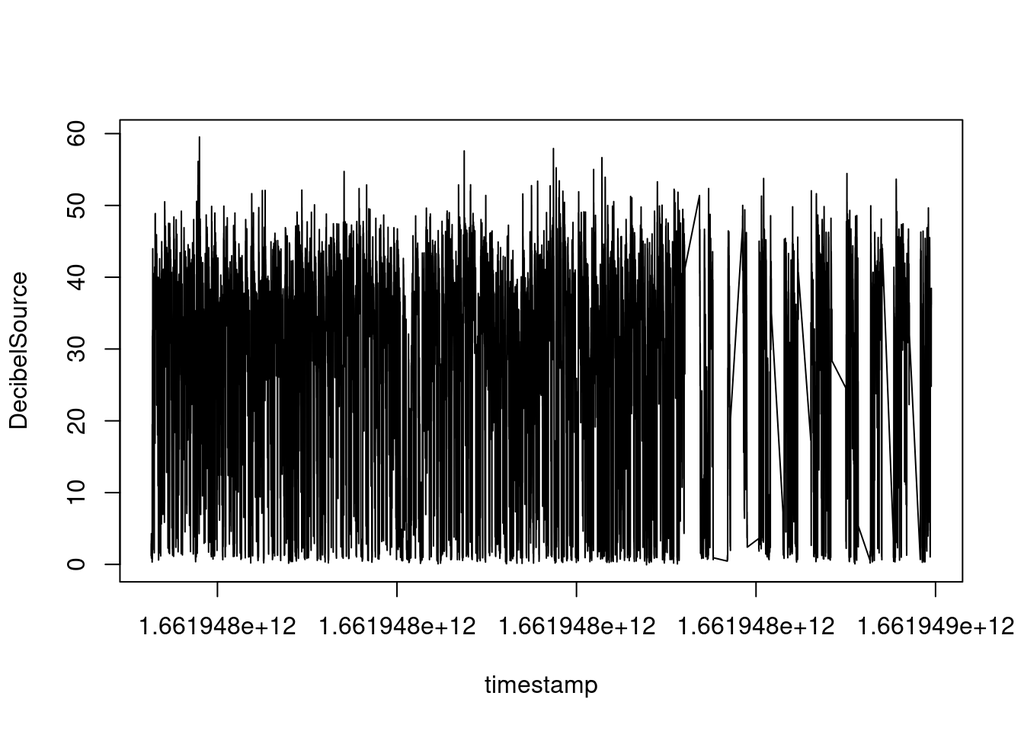

```r
plot(camilo, type="l")
```

**Mostrar codigo**

```r
camilo$timestamp[nrow(camilo)]
```

```
[1] 1.661949e+12
```

**Mostrar codigo**

```r
camilo$timestamp[nrow(camilo)] - camilo$timestamp[1]
```

```
[1] 869172
```

**Mostrar codigo**

```r
(camilo$timestamp[nrow(camilo)]-camilo$timestamp[1])/60000
```

```
[1] 14.4862
```

Exploramos la distribución de los datos

**Mostrar codigo**

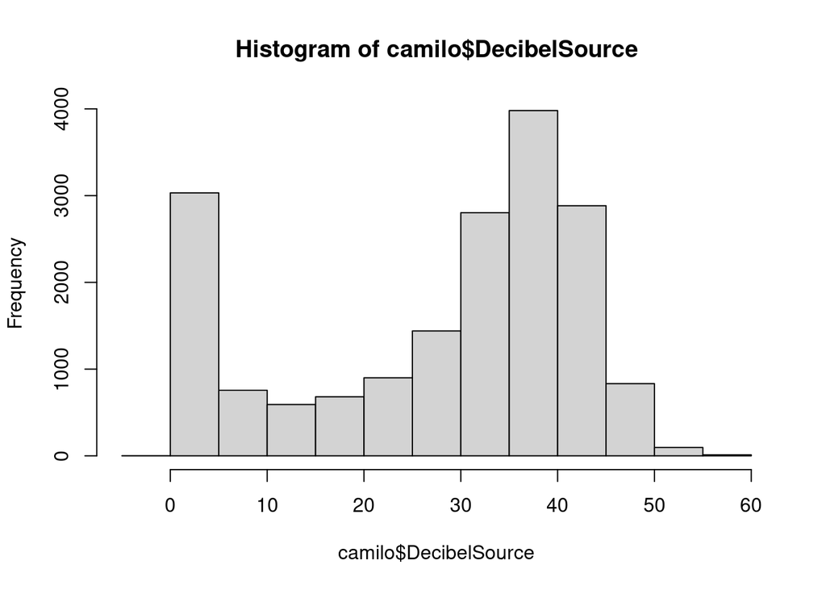

```r
hist(camilo$DecibelSource)
```

**Mostrar codigo**

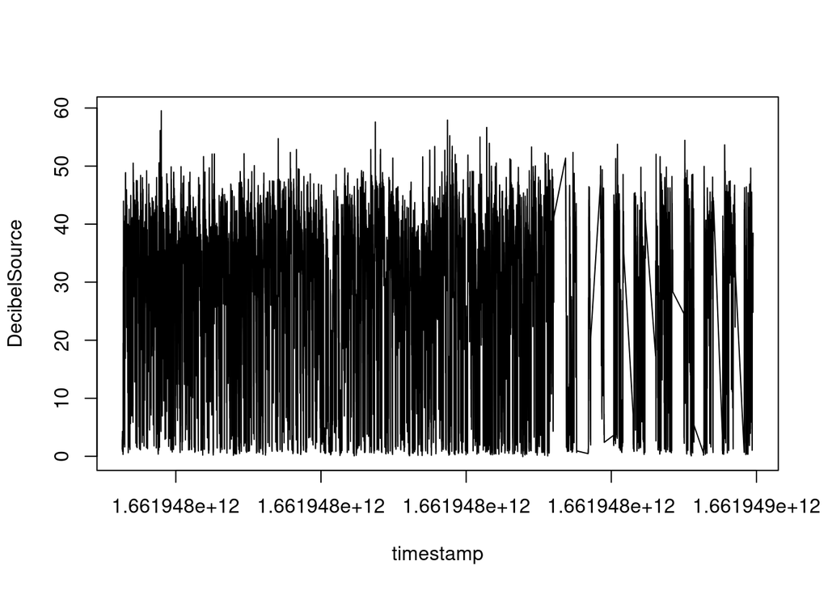

```r
with(camilo, plot(timestamp, DecibelSource, type = "l"))
```

Cargamos las coordenadas

**Mostrar codigo**

```r
coordenadas<-read.csv("coordenadas (2).csv")
names(coordenadas)
```

```
[1] "Nombre" "x"      "y"
```

**Mostrar codigo**

```r
coordenadas$y<-as.numeric(gsub(",", ".", coordenadas$y))
coordenadas
```

```
        Nombre   x     y
1    Sebastián 164  46.0
2      Esteban 397  14.0
3   John Erick 267  88.0
4  July Andrea  61  40.0
5       Camilo  60  69.0
6      Kenneth 500  63.0
7      Laura 1 202  81.0
8      Laura 2 141  80.0
9  Juan Felipe 179  29.0
10 Valentina 1 401 113.5
```

Graficamos las coordenadas

**Mostrar codigo**

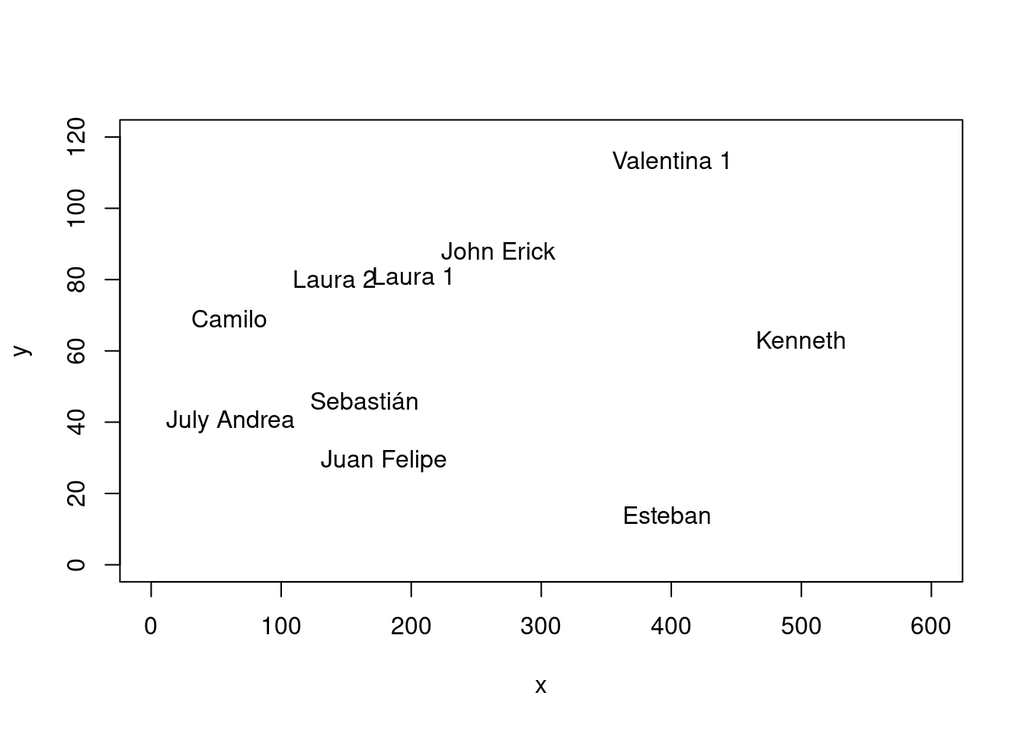

```r
with(coordenadas, plot(x,y,
                       xlim = c(0,600),
                       ylim = c(0,120),
                       type = "n"))
with(coordenadas, text(x,y, labels = Nombre))
```

como la función dist dá media matriz, entonces generamos la matriz completa y la convertimos a dataframe. LO primero se hace con la librería “reshape2”.

**Mostrar codigo**

```r
distancias<-dist(coordenadas[,-1])
distancias<-melt(as.matrix(distancias), varnames = c("Name1", "Name2"))
distancias<-as.data.frame(distancias)
distancias
```

```
    Name1 Name2     value
1       1     1   0.00000
2       2     1 235.18716
3       3     1 111.23399
4       4     1 103.17461
5       5     1 106.51291
6       6     1 336.42978
7       7     1  51.66237
8       8     1  41.04875
9       9     1  22.67157
10     10     1 246.42494
11      1     2 235.18716
12      2     2   0.00000
13      3     2 149.58610
14      4     2 337.00445
```

[output cut: 86 more lines]

dado que se generó a partir de la matriz de distancias un data frame con combinaciones repetidas, entones mediante la función “unique” generamos una unica combinación de filas (argumento 1) de manera ordenada con el argumento “sort”. POsteriormente se renombran las columnas. Dado que en la combinación se incluyó el cero, tambien se eliminó generando un subset de datos.

**Mostrar codigo**

```r
distancias <- unique(t(apply(distancias, 1, sort)))
distancias
```

```
      [,1] [,2]      [,3]
 [1,]    0    1   1.00000
 [2,]    1    2 235.18716
 [3,]    1    3 111.23399
 [4,]    1    4 103.17461
 [5,]    1    5 106.51291
 [6,]    1    6 336.42978
 [7,]    1    7  51.66237
 [8,]    1    8  41.04875
 [9,]    1    9  22.67157
[10,]    1   10 246.42494
[11,]    0    2   2.00000
[12,]    2    3 149.58610
[13,]    2    4 337.00445
[14,]    2    5 341.45864
```

[output cut: 41 more lines]

**Mostrar codigo**

```r
distancias<-as.data.frame(distancias)
distancias
```

```
   V1 V2        V3
1   0  1   1.00000
2   1  2 235.18716
3   1  3 111.23399
4   1  4 103.17461
5   1  5 106.51291
6   1  6 336.42978
7   1  7  51.66237
8   1  8  41.04875
9   1  9  22.67157
10  1 10 246.42494
11  0  2   2.00000
12  2  3 149.58610
13  2  4 337.00445
14  2  5 341.45864
```

[output cut: 41 more lines]

**Mostrar codigo**

```r
colnames(distancias)[2]="Name2"
colnames(distancias)[1]="Name1"
colnames(distancias)[3]="distancia"
distancias<-distancias[-1,]

##eliminamos los ceros generados
distancias<-subset(distancias, Name1!=0)
distancias
```

```
   Name1 Name2 distancia
2      1     2 235.18716
3      1     3 111.23399
4      1     4 103.17461
5      1     5 106.51291
6      1     6 336.42978
7      1     7  51.66237
8      1     8  41.04875
9      1     9  22.67157
10     1    10 246.42494
12     2     3 149.58610
13     2     4 337.00445
14     2     5 341.45864
15     2     6 114.06139
16     2     7 206.18923
```

[output cut: 31 more lines]

Dado que en la generación de la matriz los items quedaron como número, entonces se convierte a caracter y se reasigna el nombre correspondiente a cada número, ya que cada número corresponde al item organizado dentro del dataframe.

**Mostrar codigo**

```r
distancias$Name1<-as.character(distancias$Name1)
distancias$Name2<-as.character(distancias$Name2)

distancias$Name1[distancias$Name1 =="1"]<-"sebastian"
distancias$Name1[distancias$Name1 =="2"]<-"Esteban"
distancias$Name1[distancias$Name1 =="3"]<-"Jhon_erick"
distancias$Name1[distancias$Name1 =="4"]<-"july_andrea"
distancias$Name1[distancias$Name1 =="5"]<-"camilo"
distancias$Name1[distancias$Name1 =="6"]<-"kenneth"
distancias$Name1[distancias$Name1 =="7"]<-"laura_1"
distancias$Name1[distancias$Name1 =="8"]<-"laura2"
distancias$Name1[distancias$Name1 =="9"]<-"juan_felipe"
distancias$Name1[distancias$Name1 =="10"]<-"valentina_1"
distancias$Name2[distancias$Name2 =="1"]<-"sebastian"
distancias$Name2[distancias$Name2 =="2"]<-"Esteban"
distancias$Name2[distancias$Name2 =="3"]<-"Jhon_erick"
distancias$Name2[distancias$Name2 =="4"]<-"july_andrea"
distancias$Name2[distancias$Name2 =="5"]<-"camilo"
distancias$Name2[distancias$Name2 =="6"]<-"kenneth"
distancias$Name2[distancias$Name2 =="7"]<-"laura_1"
distancias$Name2[distancias$Name2 =="8"]<-"laura2"
distancias$Name2[distancias$Name2 =="9"]<-"juan_felipe"
distancias$Name2[distancias$Name2 =="10"]<-"valentina_1"
distancias
```

```
         Name1       Name2 distancia
2    sebastian     Esteban 235.18716
3    sebastian  Jhon_erick 111.23399
4    sebastian july_andrea 103.17461
5    sebastian      camilo 106.51291
6    sebastian     kenneth 336.42978
7    sebastian     laura_1  51.66237
8    sebastian      laura2  41.04875
9    sebastian juan_felipe  22.67157
10   sebastian valentina_1 246.42494
12     Esteban  Jhon_erick 149.58610
13     Esteban july_andrea 337.00445
14     Esteban      camilo 341.45864
15     Esteban     kenneth 114.06139
16     Esteban     laura_1 206.18923
```

[output cut: 31 more lines]

Eliminamos las milesimas de segundos

**Mostrar codigo**

```r
camilo<-camilo %>%
  mutate(timestamp1 = trunc(timestamp/1000))
jhon_erick<-jhon_erick %>%
  mutate(timestamp1 = trunc(timestamp/1000))
juan_felipe<-juan_felipe %>%
  mutate(timestamp1 = trunc(timestamp/1000))
july_andrea<-july_andrea%>%
  mutate(timestamp1 =trunc(timestamp/1000))
kenneth<-kenneth %>%
  mutate(timestamp1 = trunc(timestamp/1000))
laura_1<-laura_1 %>%
  mutate(timestamp1 = trunc(timestamp/1000))
laura_2<-laura_2 %>%
  mutate(timestamp1 = trunc(timestamp/1000))
sebastian<-sebastian %>%
  mutate(timestamp1 = trunc(timestamp/1000))
valentina_1<-valentina_1 %>%
  mutate(timestamp1 = trunc(timestamp/1000))
esteban<-esteban %>%
  mutate(timestamp1 = trunc(timestamp/1000))
```

**Mostrar codigo**

```r
length(unique(camilo$timestamp1))
```

```
[1] 737
```

generamos la columna de fecha en formato fecha y hora

**Mostrar codigo**

```r
camilo1<- camilo %>%
  group_by(timestamp1) %>%
  summarise(camilo = mean(DecibelSource, na.rm=TRUE))%>%
  mutate(fecha=as.POSIXct(timestamp1, origin = "1970-01-01"))
jhon_erick1<-jhon_erick %>%
  group_by(timestamp1) %>%
  summarise(jhon_erick = mean(DecibelSource, na.rm = TRUE))%>%
  mutate(fecha=as.POSIXct(timestamp1, origin = "1970-01-01"))
juan_felipe1<-juan_felipe %>%
  group_by(timestamp1) %>%
  summarise(juan_felipe = mean(DecibelSource, na.rm =TRUE))%>%
  mutate(fecha=as.POSIXct(timestamp1, origin = "1970-01-01"))
july_andrea1<-july_andrea %>%
  group_by(timestamp1) %>%
  summarise(july_andrea = mean(DecibelSource, na.rm =TRUE))%>%
  mutate(fecha=as.POSIXct(timestamp1, origin = "1970-01-01"))
kenneth1<-kenneth %>%
  group_by(timestamp1) %>%
  summarise(kenneth= mean(DecibelSource, na.rm =TRUE))%>%
  mutate(fecha=as.POSIXct(timestamp1, origin = "1970-01-01"))
laura_11<-laura_1 %>%
  group_by(timestamp1) %>%
  summarise(laura_1= mean(DecibelSource, na.rm =TRUE))%>%
  mutate(fecha=as.POSIXct(timestamp1, origin = "1970-01-01"))
laura22<-laura_2 %>%
  group_by(timestamp1) %>%
  summarise(laura2= mean(DecibelSource, na.rm =TRUE))%>%
  mutate(fecha=as.POSIXct(timestamp1, origin = "1970-01-01"))
sebastian1<-sebastian %>%
  group_by(timestamp1) %>%
  summarise(sebastian= mean(DecibelSource, na.rm =TRUE))%>%
  mutate(fecha=as.POSIXct(timestamp1, origin = "1970-01-01"))
valentina11<-valentina_1 %>%
  group_by(timestamp1) %>%
  summarise(valentina_1= mean(DecibelSource, na.rm =TRUE))%>%
  mutate(fecha=as.POSIXct(timestamp1, origin = "1970-01-01"))
esteban1<-esteban %>%
  group_by(timestamp1) %>%
  summarise(esteban= mean(DecibelSource, na.rm =TRUE))%>%
  mutate(fecha=as.POSIXct(timestamp1, origin = "1970-01-01"))
```

Unificamos todas las bases de datos a partir de la fecha

**Mostrar codigo**

```r
total<-camilo1%>%
  inner_join(valentina11)%>%
  inner_join(kenneth1)%>%
  inner_join(juan_felipe1)%>%
  inner_join(sebastian1)%>%
  inner_join(laura_11)%>%
  inner_join(laura22)%>%
  inner_join(july_andrea1)
total
```

```
# A tibble: 551 × 10
   timestamp1 camilo fecha               valentina_1 kenneth juan_felipe
        <dbl>  <dbl> <dttm>                    <dbl>   <dbl>       <dbl>
 1 1661947755   22.6 2022-08-31 07:09:15        50.2    32.0        28.9
 2 1661947756   22.1 2022-08-31 07:09:16        33.1    30.7        11.0
 3 1661947757   30.8 2022-08-31 07:09:17        37.5    47.1        10.7
 4 1661947758   37.6 2022-08-31 07:09:18        35.5    43.2        23.4
 5 1661947759   31.3 2022-08-31 07:09:19        51.5    42.8        37.6
 6 1661947760   28.8 2022-08-31 07:09:20        40.5    41.5        26.9
 7 1661947761   24.3 2022-08-31 07:09:21        33.7    35.7        31.2
 8 1661947762   31.1 2022-08-31 07:09:22        36.9    34.0        18.8
 9 1661947763   32.7 2022-08-31 07:09:23        39.5    41.9        14.8
10 1661947764   37.8 2022-08-31 07:09:24        45.7    39.1        23.5
# ℹ 541 more rows
# ℹ 4 more variables: sebastian <dbl>, laura_1 <dbl>, laura2 <dbl>,
#   july_andrea <dbl>
```

**Mostrar codigo**

```r
total<-total[, c(1,3,2,4,5,6,7,8,9,10)]
total
```

```
# A tibble: 551 × 10
   timestamp1 fecha               camilo valentina_1 kenneth juan_felipe
        <dbl> <dttm>               <dbl>       <dbl>   <dbl>       <dbl>
 1 1661947755 2022-08-31 07:09:15   22.6        50.2    32.0        28.9
 2 1661947756 2022-08-31 07:09:16   22.1        33.1    30.7        11.0
 3 1661947757 2022-08-31 07:09:17   30.8        37.5    47.1        10.7
 4 1661947758 2022-08-31 07:09:18   37.6        35.5    43.2        23.4
 5 1661947759 2022-08-31 07:09:19   31.3        51.5    42.8        37.6
 6 1661947760 2022-08-31 07:09:20   28.8        40.5    41.5        26.9
 7 1661947761 2022-08-31 07:09:21   24.3        33.7    35.7        31.2
 8 1661947762 2022-08-31 07:09:22   31.1        36.9    34.0        18.8
 9 1661947763 2022-08-31 07:09:23   32.7        39.5    41.9        14.8
10 1661947764 2022-08-31 07:09:24   37.8        45.7    39.1        23.5
# ℹ 541 more rows
# ℹ 4 more variables: sebastian <dbl>, laura_1 <dbl>, laura2 <dbl>,
#   july_andrea <dbl>
```

**Mostrar codigo**

```r
correla<-cor(total[, 3:10])
correla
```

```
                 camilo valentina_1    kenneth juan_felipe   sebastian
camilo       1.00000000  0.25045969 0.17643779 -0.05381136  0.13138569
valentina_1  0.25045969  1.00000000 0.06956460 -0.02365206  0.04276912
kenneth      0.17643779  0.06956460 1.00000000  0.03909142  0.79508422
juan_felipe -0.05381136 -0.02365206 0.03909142  1.00000000 -0.14706071
sebastian    0.13138569  0.04276912 0.79508422 -0.14706071  1.00000000
laura_1      0.10639811 -0.01351914 0.21748105  0.53671323  0.02685449
laura2       0.35422445  0.38123098 0.28528940  0.02441829  0.18162917
july_andrea  0.11479718  0.03658782 0.79127668 -0.02616454  0.80891785
                laura_1     laura2 july_andrea
camilo       0.10639811 0.35422445  0.11479718
valentina_1 -0.01351914 0.38123098  0.03658782
kenneth      0.21748105 0.28528940  0.79127668
juan_felipe  0.53671323 0.02441829 -0.02616454
sebastian    0.02685449 0.18162917  0.80891785
laura_1      1.00000000 0.14687957  0.07820671
laura2       0.14687957 1.00000000  0.20687115
july_andrea  0.07820671 0.20687115  1.00000000
```

Al igual que la matriz de distancias, convertimos la matriz de correlación como matriz (por defecto la convirtió a dataframee)

**Mostrar codigo**

```r
correla<-melt(as.matrix(correla), varnames = c("Name1", "Name2"))
correla$Name1<-as.character(correla$Name1)
correla$Name2<-as.character(correla$Name2)
correla
```

```
         Name1       Name2       value
1       camilo      camilo  1.00000000
2  valentina_1      camilo  0.25045969
3      kenneth      camilo  0.17643779
4  juan_felipe      camilo -0.05381136
5    sebastian      camilo  0.13138569
6      laura_1      camilo  0.10639811
7       laura2      camilo  0.35422445
8  july_andrea      camilo  0.11479718
9       camilo valentina_1  0.25045969
10 valentina_1 valentina_1  1.00000000
11     kenneth valentina_1  0.06956460
12 juan_felipe valentina_1 -0.02365206
13   sebastian valentina_1  0.04276912
14     laura_1 valentina_1 -0.01351914
```

[output cut: 50 more lines]

Unimos los nombres en la medida que índiquen la interacción entre si (cabe resaltar que quedan los items, es decir los nombres repetidos que más adelante se eliminarań cuando se únifiquen la matriz de distancias y de correlación)

**Mostrar codigo**

```r
correla<-correla%>%
  unite('par_nombres', Name1:Name2, remove = FALSE)
correla
```

```
               par_nombres       Name1       Name2       value
1            camilo_camilo      camilo      camilo  1.00000000
2       valentina_1_camilo valentina_1      camilo  0.25045969
3           kenneth_camilo     kenneth      camilo  0.17643779
4       juan_felipe_camilo juan_felipe      camilo -0.05381136
5         sebastian_camilo   sebastian      camilo  0.13138569
6           laura_1_camilo     laura_1      camilo  0.10639811
7            laura2_camilo      laura2      camilo  0.35422445
8       july_andrea_camilo july_andrea      camilo  0.11479718
9       camilo_valentina_1      camilo valentina_1  0.25045969
10 valentina_1_valentina_1 valentina_1 valentina_1  1.00000000
11     kenneth_valentina_1     kenneth valentina_1  0.06956460
12 juan_felipe_valentina_1 juan_felipe valentina_1 -0.02365206
13   sebastian_valentina_1   sebastian valentina_1  0.04276912
14     laura_1_valentina_1     laura_1 valentina_1 -0.01351914
```

[output cut: 50 more lines]

AL igual que en la matriz de correlación, unimos los nombres en la medida de la interacción entre si

**Mostrar codigo**

```r
distancias<-distancias%>%
  unite('par_nombres', Name1:Name2, remove = FALSE)
distancias
```

```
               par_nombres       Name1       Name2 distancia
2        sebastian_Esteban   sebastian     Esteban 235.18716
3     sebastian_Jhon_erick   sebastian  Jhon_erick 111.23399
4    sebastian_july_andrea   sebastian july_andrea 103.17461
5         sebastian_camilo   sebastian      camilo 106.51291
6        sebastian_kenneth   sebastian     kenneth 336.42978
7        sebastian_laura_1   sebastian     laura_1  51.66237
8         sebastian_laura2   sebastian      laura2  41.04875
9    sebastian_juan_felipe   sebastian juan_felipe  22.67157
10   sebastian_valentina_1   sebastian valentina_1 246.42494
12      Esteban_Jhon_erick     Esteban  Jhon_erick 149.58610
13     Esteban_july_andrea     Esteban july_andrea 337.00445
14          Esteban_camilo     Esteban      camilo 341.45864
15         Esteban_kenneth     Esteban     kenneth 114.06139
16         Esteban_laura_1     Esteban     laura_1 206.18923
```

[output cut: 31 more lines]

Unimos las matrices en función de unir los mismos nombres (los cuales son las interacciones entre si)

**Mostrar codigo**

```r
correla_distancias<-merge(x = distancias, y = correla, by = "par_nombres")
correla_distancias
```

```
               par_nombres     Name1.x     Name2.x distancia     Name1.y
1       camilo_juan_felipe      camilo juan_felipe 125.54282      camilo
2           camilo_kenneth      camilo     kenneth 440.04091      camilo
3           camilo_laura_1      camilo     laura_1 142.50614      camilo
4            camilo_laura2      camilo      laura2  81.74350      camilo
5       camilo_valentina_1      camilo valentina_1 343.89133      camilo
6  juan_felipe_valentina_1 juan_felipe valentina_1 237.53789 juan_felipe
7       july_andrea_camilo july_andrea      camilo  29.01724 july_andrea
8  july_andrea_juan_felipe july_andrea juan_felipe 118.51160 july_andrea
9      july_andrea_kenneth july_andrea     kenneth 439.60209 july_andrea
10     july_andrea_laura_1 july_andrea     laura_1 146.84005 july_andrea
11      july_andrea_laura2 july_andrea      laura2  89.44272 july_andrea
12 july_andrea_valentina_1 july_andrea valentina_1 347.85378 july_andrea
13     kenneth_juan_felipe     kenneth juan_felipe 322.79560     kenneth
14         kenneth_laura_1     kenneth     laura_1 298.54313     kenneth
```

[output cut: 43 more lines]

ELiminamos las columnas de más que se generaron en la unión (merge)

**Mostrar codigo**

```r
correla_distancias<-correla_distancias[, -c(2,3,5,6)]
correla_distancias
```

```
               par_nombres distancia       value
1       camilo_juan_felipe 125.54282 -0.05381136
2           camilo_kenneth 440.04091  0.17643779
3           camilo_laura_1 142.50614  0.10639811
4            camilo_laura2  81.74350  0.35422445
5       camilo_valentina_1 343.89133  0.25045969
6  juan_felipe_valentina_1 237.53789 -0.02365206
7       july_andrea_camilo  29.01724  0.11479718
8  july_andrea_juan_felipe 118.51160 -0.02616454
9      july_andrea_kenneth 439.60209  0.79127668
10     july_andrea_laura_1 146.84005  0.07820671
11      july_andrea_laura2  89.44272  0.20687115
12 july_andrea_valentina_1 347.85378  0.03658782
13     kenneth_juan_felipe 322.79560  0.03909142
14         kenneth_laura_1 298.54313  0.21748105
15          kenneth_laura2 359.40228  0.28528940
16     kenneth_valentina_1 111.13618  0.06956460
17     laura_1_juan_felipe  56.85948  0.53671323
18          laura_1_laura2  61.00820  0.14687957
19     laura_1_valentina_1 201.63643 -0.01351914
20      laura2_juan_felipe  63.60031  0.02441829
21      laura2_valentina_1 262.14929  0.38123098
22        sebastian_camilo 106.51291  0.13138569
23   sebastian_juan_felipe  22.67157 -0.14706071
24   sebastian_july_andrea 103.17461  0.80891785
25       sebastian_kenneth 336.42978  0.79508422
26       sebastian_laura_1  51.66237  0.02685449
27        sebastian_laura2  41.04875  0.18162917
28   sebastian_valentina_1 246.42494  0.04276912
```

**Mostrar codigo**

```r
colnames(correla_distancias)[2]="distancia"
colnames(correla_distancias)[3]="correlacion"
correla_distancias$distancia<-as.numeric(correla_distancias$distancia)
correla_distancias$correlacion<-as.numeric(correla_distancias$correlacion)
```

**Mostrar codigo**

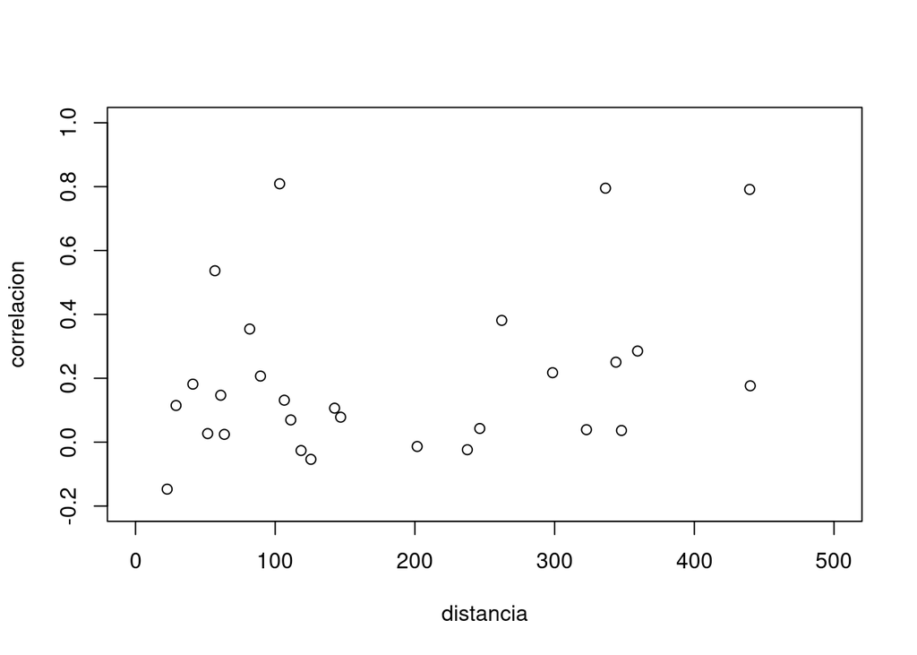

```r
with(correla_distancias, plot(distancia,correlacion,
                       xlim = c(-0.1,500),
                       ylim = c(-0.2,1)))
```